# IE 582 - Project Report - Group Id: 8

Ahmet Pala, Gizem Kurtbay

3 January 2019

# INTRODUCTION

The aim of this project is to forecast the probabilities od the 1x2 bets results of the football matches using the data of previous matches and odds. The data can be performance of the teams for the last 5 matches, odds data, day of the match, and other possible features that can give better predictions compared to predictions of other bookmakers. This can be thought as a classification problem since we could generate predictions for home win, tie win and away win, but it will be considered as regression problem due to the nature of the target class. To explain better, if a match score is 1:0 (home win), the result cannot turn into an away win (1:2) without being tie win (1:1) before. Therefore, it is decided to use multinomial logistic regression (lasso) model and stochastic gradient boosting model for the predictions in this project by finding and using the features that gives the best predictions.

Multinomial logistic regression model (lasso) is a regression analysis that performs both selection of variables and regularization to increase the accuracy of the predictions. Choosing the best lambda value that gives the smallest RPS value plays a key role in the multinomial logistic regression model (lasso), and cross validation is used in this aim. Lasso selects only a subset of the provided covariates for use in the final model rather than using all of them. Lasso penalty uses the absolute values (beta) instead of least squares. Penalized regression analysis revolves around an assumption that coefficient values around zero are more believable compared to the values far away from zero. Lasso is forcing the sum of the absolute value of the regression coefficients to be less than a fixed value, which sets the value of certain coefficients to zero, effectively choosing a simpler model that does not include those certain coefficients. Glmnet is used for penalized regression in R coding.

Stochastic gradient boosting works by constructing additive regression models by sequentially fitting a simple parameterized function, a base learner, to current pseudo-residuals by least squares at each iteration. With respect to the model values at each training data point evaluated at the current step, the pseudo-residuals give the gradient of the loss functional which is being minimized. Approximation accuracy and execution speed of stochastic gradient boosting can be improved by adding randomization into the procedure. This randomization can be obtained by taking a subsample of training data from the whole training set randomly and without replacement. The subsample taken can be used instead of the whole training dataset to fit the base learner and to update the model at each iteration. This randomization in selecting the training dataset subsample increases the robustness against overcapacity of the base learner.[1] Multinomial case can be used in stochastic gradient boosting since we have tree classes which are home, tie, away.

In the original given data there are features in the matches and odds. In matches, there are leagueId, matchId, home, away, score, date and type. LeagueId was always England Premiere League and the type is always soccer. MacthId is different for each match. Home and away represents the name of the teams playing. The score is represented as home:away. Date is turned into a number using as.factor in R coding. In odds, there are matchId, betType, oddtype, bookmaker, date, odd. MacthId is different for each match and we can use matchId to merge match and odd data since it is specific for each match. BetType is always 1x2 which represents home, tie and away. Bookmaker has the names of the different bookmakers. Date is again turned into a number using as.factor in R coding. The odds are given as numbers for each match by the bookmakers. Odds are basically the ratios of the results for 1x2 given by the bookmakers.

# RELATED LITERATURE

In the literature for predicting sports results, machine learning is used. Supervised and unsupervised learning are used in machine learning. In supervised learning, predictive model is developed both on input and output data, using classification and regression methods. In unsupervised learning, only input data is used for interpretation, using the clustering method. Sport results prediction is usually treated as a classification problem, with one class (win, lose, or tie) to be predicted. Some predictions are done as numeric predictions by using winning margin. In sport result predictions, large number of features can be collected and used such as historical performance of the teams and results of matches. [2]

Artificial Neural Networks (ANNs) are probably the most commonly applied approach among machine learning mechanisms to the sport result prediction problem. ANNs usually have neurons which are interconnected components which transform a set of inputs to a desired output by adjusting weights that contribute to the final decision. The weights associated with these interconnected components are changing continuously to have high accuracy in predictions. ANN algorithm is used for high accuracy which can cause overfitting and wasting computer resources like training time and memory. However, a good feature of ANN is being flexible about the definition of class variables. [2]

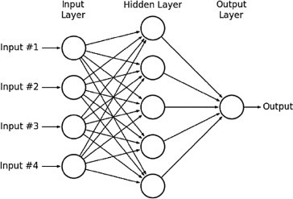

Figure: ANN Example with 4 input nodes, 5 hidden layer nodes and 1 output node [2]

Purucker managed an initial study by using an ANN model to predict National Football league results and achieved 61% accuracy compared with 72% accuracy of the domain experts. The BP algorithm was found as the most effective approach. A limitation of this study is that only five features were used which is a relatively small number. [2]

Kahn used total yardage differential, rushing yardage differential, turnover differential, away team indicator and home team indicator as the features for the predictions of home team outcome and away team outcome. Kahn obtained 75% accuracy while the domains experts had 63% accuracy on average on the same matches. [2]

McCabe and Trevathan tried to predict results in four different sport areas which are NFL (Rugby League), AFL (Australian Rules football), Super Rugby (Rugby Union), and English Premier League Football (EPL) and used the data sets back to 2002. The ANN that is used had 20 input nodes, 10 hidden layer nodes and 1 output node in the model. The ANN had 67.5% accuracy while other expert predictors had 60% - 65% accuracy values. [2]

# APPROACH

Two approaches are used in this project, which are multinomial logistic regression model (lasso) and stochastic gradient boosting model. The package ‘glmnet’ is used for penalized regression and ‘gbm’ package is used for stochastic gradient boosting model. Then RPS is used as performance metric.

The matches data is taken and preprocessed to be ready for further usage in the code. After preprocessing, the new dataset has leagueId, matchId, home, away, match date, type, weekday, month, match hour, home score, away score, match result and total score. LeagueId is always England Premiere League and the type is always soccer. MacthId is different for each match. Home and away represents the name of the teams playing in that match. Match date was first obtained as year-month-date using ‘anydate’ package in R coding. Week day, month and match hour are obtained from the date using ‘anytime’ package in R coding, then they are changed to factors using ‘as.factor’ package in R coding . Home score, away score and total score are obtained individually as numbers. Match results are given as home, tie and away.

The dataset of odds is also preprocessed. First of all, only 1x2 bet type was considered. The bookmakers that gives odds for 1x2 bet type are taken into consideration. OddChageDateTime data is added to the dataset. Odds stayed as numbers while match dates are obtained as dates in the structure of year-month-day.

The features from matches and odds are merged together by using their matchId’s. There are opening and closing odds for each match’s possible result (home, tie, away) for each bookmaker which gives odds for 1x2 bet type, and they are both used since the difference between opening and closing odds are considered as important. In the final dataset, there are matchId, leagueId, match date, weekday, moth, match hour, match result, opening and closing odds for each bookmaker which gives odds for 1x2 bet type.

The data is divided into two as train and test data and this division is done according to the dates of the matches. The date of the prediction is considered and matches with dates before the current date is considered as train data while the future dates are considered as test data. Therefore, test data has no results in the day that predictions are performed. The aim is to predict the probabilities of the results for each match accurately and RPS formulation is used for that, and RPS result is tried to be minimized.

In the aim of obtaining accurate prediction results, optimum lambda values are calculated for logistic regression by doing 10-fold cross validation with three replications and tuned accordingly based on the RPS performance trying to minimize the RPS value. Lambda is a parameter that controls the overall level (intensity) of regularization. The ?? value that minimizes the out of fold deviance is tried to be chosen, the largest ?? one standard deviation away from the minimizer lambda is chosen heuristically. [3]

Multinomial case is used in stochastic gradient boosting in R-coding since we have tree classes which are home, tie, away. The preprocessed data is changed before being used for stochastic gradient boosting. NA instances in the data set are omitted since ‘gbm’ package cannot work with NA instances. For the stochastic gradient boosting model, 10-fold cross validation is done in order to prevent overfitting. Then model is obtained and used on the test data. Relative influences of features are also obtained during the R coding.

Ranked Probability Score is used as a measure of accuracy of the predictions. Probability distributions are used to express the relation between match results and predictions. Spread of the forecast distribution and location are considered to decide the closeness relation of the observed value and the distribution. The equation below is used for the RPS calculations.

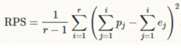

In the equation above; r represents the number of outcomes, pj represents the forecasted probability of outcome j and ej represents the actual probability of outcome j. In our project, predictions for 1x2 bets are done which means there are three types of outcome which are home, tie and away, therefore the value of r is 3 in this forecasting. The RPS values are calculated for each match in the test data, and by taking the average of each RPS results, average RPS is obtained for that test data.

# RESULTS

In this part, two different models (multinomial - penalized logistic regression and stochastic gradient boosting model) were used for predicting the probabilities of possible outcomes of match results (Homewin ,Tie, Awaywin). For each round (from round 14 to round 21), after preprocessing the data, the dataset was split into two parts: train and test data (Note that the odd data was filtered. Only the odds of the bookmakers which gave odds in type 1x2 for the matches were considered). This split was carried out based on the date of the instances (matches). Before starting the analysis, from the date 2012-07-15 to the date of the first match of that round was defined as the train data set interval, and the matches in that interval constitute the train data. From the date of the first match of that round to the present was defined as the test data interval, and the matches in that interval constitute the test data. Moreover, two different models were created based on the train data set for each round, and average RPS value for train data set was calculated for both multinomial-penalized logistic regression and stochastic gradient boosting method. After getting the match results, RPS calculations were also carried out for the predictions (for particular 10 matches) for the corresponding round.

The first submission (Round 14) is done with multinomial penalized logistic regression. Then, stochastic gradient boosting model is created and tried. After that the RPS values of the two models are obtained with the results of the test data of the 14th round. Lower RPS values are obtained with the results of the test data by using multinomial penalized logistic regression, therefore multinomial penalized logistic regression is used for the second submission thinking that better results will be obtained with multinomial penalized logistic regression since there are low number of test data and multinomial penalized logistic regression is more robust compared to stochastic gradient boosting. After that, both of the methods are tried each week with the results of the previous weeks match data and it is seen that multinomial penalized logistic regression gives lower RPS values each week, therefore the submissions are done by using multinomial penalized logistic regression to obtain better predictions with lower RPS values.

## Round 14

### Multinomial Logistic Regression Model (with l1 penalty, i.e. LASSO)

```
## Number of bookmakers with proportion of missings below 0.01 since 2012-07-15 : 14
## Number of bookmakers with no missings since testStart 2018-11-30 : 4
```

```
## [1] "Average RPS for train data (multinomial penalized logistic regression)"
## [2] "0.19249883242183"
```

Average rps value was obtained for train data. Now, the model will be used for predicting the probabilities of possible outcomes of match result for the test data.

```
## [1] "Predictions for round 14 (multinomial penalized logistic regression)"
```

```
##      matchId            home           away      Home        Tie
##  1: 8Gl5Kfhj       leicester        watford 0.4353870 0.29327474
##  2: 8pSKbJs5         cardiff         wolves 0.3139708 0.26652959
##  3: EDuesIa3       newcastle       west-ham 0.4019809 0.29605058
##  4: IoAQRx0G         arsenal      tottenham 0.3940048 0.29999912
##  5: Qia0Lzwp    huddersfield       brighton 0.4083162 0.29203269
##  6: dx9UQdFM         chelsea         fulham 0.8439013 0.09335322
##  7: dxVatxF9     southampton manchester-utd 0.2898345 0.25561089
##  8: ja8YPGUS  crystal-palace        burnley 0.5470781 0.25571197
##  9: n7m9JE7d       liverpool        everton 0.6696779 0.19258457
## 10: zNtirbpc manchester-city    bournemouth 0.9662858 0.02030914
##           Away
##  1: 0.27133828
##  2: 0.41949965
##  3: 0.30196856
##  4: 0.30599603
##  5: 0.29965107
##  6: 0.06274552
##  7: 0.45455466
##  8: 0.19720992
##  9: 0.13773753
## 10: 0.01340509
```

### Stochastic Gradient Boosting

```
## [1] "Relative influences of the features"
```

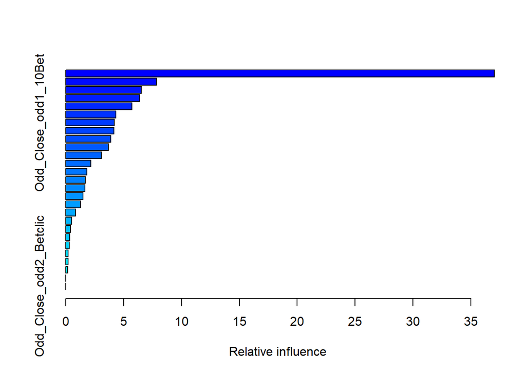

```
##                                               var    rel.inf
## Odd_Close_odd2_Betway       Odd_Close_odd2_Betway 37.0178071
## Month                                       Month  7.8343943
## Odd_Open_odd2_BetVictor   Odd_Open_odd2_BetVictor  6.5338374
## Odd_Open_odd2_10Bet           Odd_Open_odd2_10Bet  6.3899439
## Odd_Close_odd1_Betclic     Odd_Close_odd1_Betclic  5.7337823
## Odd_Close_odd2_BetVictor Odd_Close_odd2_BetVictor  4.3401836
## Odd_Close_odd1_10Bet         Odd_Close_odd1_10Bet  4.1804792
## Odd_Close_odd1_BetVictor Odd_Close_odd1_BetVictor  4.1564529
## Odd_Close_oddX_Betway       Odd_Close_oddX_Betway  3.8757460
## Odd_Open_odd1_Betclic       Odd_Open_odd1_Betclic  3.6761645
## Odd_Open_odd1_10Bet           Odd_Open_odd1_10Bet  3.0827176
## Odd_Open_odd1_Betway         Odd_Open_odd1_Betway  2.1812335
## Odd_Close_odd2_10Bet         Odd_Close_odd2_10Bet  1.8335688
## Match_Hour                             Match_Hour  1.6902709
## Odd_Open_oddX_Betclic       Odd_Open_oddX_Betclic  1.6582346
## Weekday                                   Weekday  1.4780492
## Odd_Open_odd2_Betclic       Odd_Open_odd2_Betclic  1.2917339
## Odd_Open_oddX_10Bet           Odd_Open_oddX_10Bet  0.8384537
## Odd_Close_oddX_Betclic     Odd_Close_oddX_Betclic  0.5227207
## Odd_Close_oddX_10Bet         Odd_Close_oddX_10Bet  0.4108097
## Odd_Open_oddX_Betway         Odd_Open_oddX_Betway  0.3523434
## Odd_Close_odd1_Betway       Odd_Close_odd1_Betway  0.3248759
## Odd_Open_odd2_Betway         Odd_Open_odd2_Betway  0.2094951
## Odd_Open_oddX_BetVictor   Odd_Open_oddX_BetVictor  0.2065562
## Odd_Close_oddX_BetVictor Odd_Close_oddX_BetVictor  0.1801457
## Odd_Open_odd1_BetVictor   Odd_Open_odd1_BetVictor  0.0000000
## Odd_Close_odd2_Betclic     Odd_Close_odd2_Betclic  0.0000000
```

```
## [1] "Average RPS for traindata (stochastic gradient boosting)"
## [2] "0.183597838868256"
```

Average rps value was obtained for train data. Now, the model will be used for predicting the probabilities of possible outcomes of match result for the test data.

```
## [1] "Predictions for round 14 (stochastic gradient boosting)"
```

```
##      matchId            home           away      Home       Tie       Away
##  1: 8Gl5Kfhj       leicester        watford 0.3785639 0.4263881 0.19504794
##  2: 8pSKbJs5         cardiff         wolves 0.2127606 0.2775621 0.50967726
##  3: dx9UQdFM         chelsea         fulham 0.8541007 0.1075601 0.03833922
##  4: dxVatxF9     southampton manchester-utd 0.1686632 0.3228181 0.50851869
##  5: EDuesIa3       newcastle       west-ham 0.2907032 0.4733245 0.23597231
##  6: IoAQRx0G         arsenal      tottenham 0.4492065 0.3225854 0.22820811
##  7: ja8YPGUS  crystal-palace        burnley 0.4422857 0.4125279 0.14518640
##  8: n7m9JE7d       liverpool        everton 0.8093293 0.1275487 0.06312203
##  9: Qia0Lzwp    huddersfield       brighton 0.3289635 0.5327990 0.13823745
## 10: zNtirbpc manchester-city    bournemouth 0.7251221 0.2322656 0.04261225
```

### RPS Calculations for Predicted Matches

After getting the match results, average RPS values were calculated for the outcomes of two algorithms.

```
## [1] "Average RPS for test data (multinomial penalized logistic regression)"
## [2] "0.174914889437004"
```

```
## [1] "Average RPS for testdata (stochastic gradient boosting)"
## [2] "0.196896337914068"
```

## Round 16

### Multinomial Logistic Regression Model (with l1 penalty, i.e. LASSO)

```
## Number of bookmakers with proportion of missings below 0.01 since 2012-07-15 : 15
## Number of bookmakers with no missings since testStart 2018-12-08 : 14
```

```
## [1] "Average RPS for train data (multinomial penalized logistic regression)"
## [2] "0.191733176545085"
```

Average rps value was obtained for train data. Now, the model will be used for predicting the probabilities of possible outcomes of match result for the test data.

```
## [1] "Predictions for round 16 (multinomial penalized logistic regression)"
```

```
##      matchId           home            away      Home       Tie      Away
##  1: 8AZxhZDL    bournemouth       liverpool 0.2655691 0.2435034 0.4909275
##  2: 8Ae87ED8       west-ham  crystal-palace 0.4285729 0.2976725 0.2737546
##  3: GG8MqBL1 manchester-utd          fulham 0.6820558 0.1884420 0.1295023
##  4: KlFDoXjk        everton         watford 0.4868928 0.2856283 0.2274789
##  5: QRF9nDyq        chelsea manchester-city 0.3108773 0.2754810 0.4136416
##  6: UJzZhFbF        arsenal    huddersfield 0.7317356 0.1600268 0.1082375
##  7: buEHpi6e      leicester       tottenham 0.3218943 0.2783298 0.3997759
##  8: f77QrVz8      newcastle          wolves 0.3816358 0.2954257 0.3229386
##  9: jZOsigTR        burnley        brighton 0.3831301 0.2948100 0.3220599
## 10: tbQSdcCH        cardiff     southampton 0.3782059 0.2957321 0.3260619
```

### Stochastic Gradient Boosting

```
## [1] "Relative influences of the features"
```

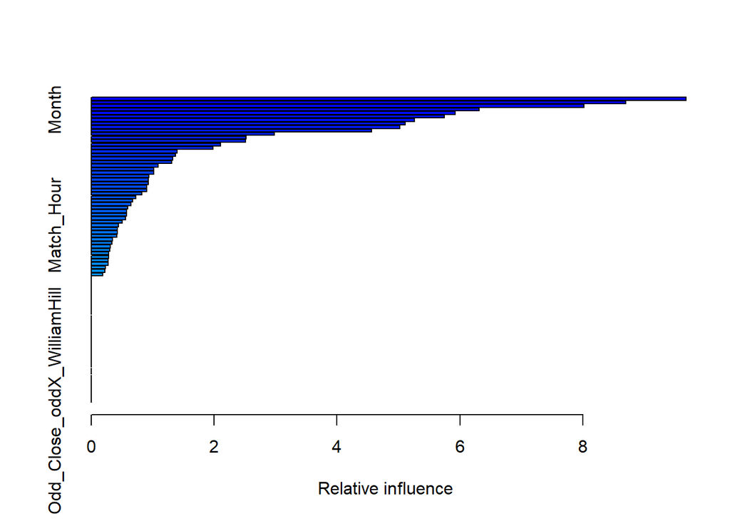

```
##                                                   var   rel.inf
## Odd_Close_odd2_bwin               Odd_Close_odd2_bwin 9.6776194
## Odd_Open_odd2_188BET             Odd_Open_odd2_188BET 8.6935323
## Odd_Close_odd1_Betclic         Odd_Close_odd1_Betclic 8.0198442
## Month                                           Month 6.3139690
## Odd_Open_odd1_10Bet               Odd_Open_odd1_10Bet 5.9187859
## Odd_Close_odd1_BetVictor     Odd_Close_odd1_BetVictor 5.7483210
## Odd_Open_odd1_Unibet             Odd_Open_odd1_Unibet 5.2622384
## Odd_Open_odd2_betathome       Odd_Open_odd2_betathome 5.1057169
## Odd_Open_odd2_Betway             Odd_Open_odd2_Betway 5.0221764
## Odd_Open_odd1_Betway             Odd_Open_odd1_Betway 4.5621253
## Odd_Close_oddX_188BET           Odd_Close_oddX_188BET 2.9816869
## Odd_Close_odd1_SBOBET           Odd_Close_odd1_SBOBET 2.5225082
## Odd_Open_odd1_bet365             Odd_Open_odd1_bet365 2.5075692
## Odd_Close_odd2_betathome     Odd_Close_odd2_betathome 2.1077431
## Odd_Open_odd1_Betsafe           Odd_Open_odd1_Betsafe 1.9829488
## Odd_Close_odd2_12BET             Odd_Close_odd2_12BET 1.3964541
## Odd_Close_odd2_BetVictor     Odd_Close_odd2_BetVictor 1.3748944
## Odd_Close_odd2_bet365           Odd_Close_odd2_bet365 1.3296640
## Odd_Open_odd1_12BET               Odd_Open_odd1_12BET 1.3058507
## Odd_Close_odd1_Betsson         Odd_Close_odd1_Betsson 1.0859132
## Odd_Close_oddX_12BET             Odd_Close_oddX_12BET 1.0182677
## Odd_Open_oddX_Betsafe           Odd_Open_oddX_Betsafe 1.0157135
## Weekday                                       Weekday 0.9406575
## Odd_Open_oddX_12BET               Odd_Open_oddX_12BET 0.9300216
## Odd_Open_odd2_12BET               Odd_Open_odd2_12BET 0.9274624
## Odd_Close_oddX_bet365           Odd_Close_oddX_bet365 0.9046459
## Odd_Close_odd2_Unibet           Odd_Close_odd2_Unibet 0.9036790
## Odd_Close_odd2_188BET           Odd_Close_odd2_188BET 0.8222112
## Odd_Open_oddX_betathome       Odd_Open_oddX_betathome 0.7300941
## Odd_Close_oddX_Unibet           Odd_Close_oddX_Unibet 0.6691066
## Odd_Open_odd2_bwin                 Odd_Open_odd2_bwin 0.6425640
## Odd_Open_odd2_10Bet               Odd_Open_odd2_10Bet 0.5899435
## Odd_Close_odd1_Unibet           Odd_Close_odd1_Unibet 0.5750751
## Odd_Open_oddX_188BET             Odd_Open_oddX_188BET 0.5724995
## Odd_Open_oddX_SBOBET             Odd_Open_oddX_SBOBET 0.5534935
## Odd_Open_oddX_WilliamHill   Odd_Open_oddX_WilliamHill 0.5053023
## Match_Hour                                 Match_Hour 0.4392119
## Odd_Open_oddX_Betclic           Odd_Open_oddX_Betclic 0.4270141
## Odd_Close_odd1_WilliamHill Odd_Close_odd1_WilliamHill 0.4252911
```

[output cut: 33 more lines]

```
## Odd_Close_odd1_betathome     Odd_Close_odd1_betathome 0.0000000
## Odd_Close_odd1_bwin               Odd_Close_odd1_bwin 0.0000000
## Odd_Close_odd2_10Bet             Odd_Close_odd2_10Bet 0.0000000
## Odd_Close_odd2_Betclic         Odd_Close_odd2_Betclic 0.0000000
## Odd_Close_odd2_Betsafe         Odd_Close_odd2_Betsafe 0.0000000
## Odd_Close_odd2_Betsson         Odd_Close_odd2_Betsson 0.0000000
## Odd_Close_odd2_Betway           Odd_Close_odd2_Betway 0.0000000
## Odd_Close_odd2_WilliamHill Odd_Close_odd2_WilliamHill 0.0000000
## Odd_Close_oddX_10Bet             Odd_Close_oddX_10Bet 0.0000000
## Odd_Close_oddX_Betclic         Odd_Close_oddX_Betclic 0.0000000
## Odd_Close_oddX_Betsafe         Odd_Close_oddX_Betsafe 0.0000000
## Odd_Close_oddX_Betsson         Odd_Close_oddX_Betsson 0.0000000
## Odd_Close_oddX_Betway           Odd_Close_oddX_Betway 0.0000000
## Odd_Close_oddX_SBOBET           Odd_Close_oddX_SBOBET 0.0000000
## Odd_Close_oddX_WilliamHill Odd_Close_oddX_WilliamHill 0.0000000
```

```
## [1] "Average RPS for traindata (stochastic gradient boosting)"
## [2] "0.180745384621212"
```

Average rps value was obtained for train data. Now, the model will be used for predicting the probabilities of possible outcomes of match result for the test data.

```
## [1] "Predictions for round 16 (stochastic gradient boosting)"
```

```
##      matchId           home            away      Home       Tie       Away
##  1: 8Ae87ED8       west-ham  crystal-palace 0.4221755 0.3704834 0.20734104
##  2: 8AZxhZDL    bournemouth       liverpool 0.2086212 0.2984791 0.49289970
##  3: buEHpi6e      leicester       tottenham 0.2479463 0.2844207 0.46763305
##  4: f77QrVz8      newcastle          wolves 0.1714594 0.5558825 0.27265807
##  5: GG8MqBL1 manchester-utd          fulham 0.7526170 0.1906192 0.05676389
##  6: jZOsigTR        burnley        brighton 0.2359598 0.5223229 0.24171727
##  7: KlFDoXjk        everton         watford 0.5262026 0.3199619 0.15383552
##  8: QRF9nDyq        chelsea manchester-city 0.2116443 0.2612034 0.52715228
##  9: tbQSdcCH        cardiff     southampton 0.2826178 0.3985344 0.31884776
## 10: UJzZhFbF        arsenal    huddersfield 0.7780212 0.1710441 0.05093469
```

### RPS Calculations for Predicted Matches

After getting the match results, average RPS values were calculated for the outcomes of two algorithms.

```
## [1] "Average RPS for test data (multinomial penalized logistic regression)"
## [2] "0.195631585253182"
```

```
## [1] "Average RPS for testdata (stochastic gradient boosting)"
## [2] "0.207779266659385"
```

## Round 17

### Multinomial Logistic Regression Model (with l1 penalty, i.e. LASSO)

```
## Number of bookmakers with proportion of missings below 0.01 since 2012-07-15 : 15
## Number of bookmakers with no missings since testStart 2018-12-15 : 15
```

```
## [1] "Average RPS for train data (multinomial penalized logistic regression)"
## [2] "0.1917053626795"
```

Average rps value was obtained for train data. Now, the model will be used for predicting the probabilities of possible outcomes of match result for the test data.

```
## [1] "Predictions for round 17 (multinomial penalized logistic regression)"
```

```
##      matchId            home           away      Home        Tie
##  1: 4xkH5hrL  crystal-palace      leicester 0.4001798 0.29780632
##  2: EBzm0W5r    huddersfield      newcastle 0.3986640 0.29711424
##  3: MDaC6YSE        brighton        chelsea 0.1452169 0.14064295
##  4: MsR7e8KD          wolves    bournemouth 0.4539690 0.29482907
##  5: h2ZjajLl       liverpool manchester-utd 0.5351600 0.26692073
##  6: hzgduVtp         watford        cardiff 0.5317478 0.26632990
##  7: lUSacUk1     southampton        arsenal 0.3122824 0.27158381
##  8: rTmL4CcR          fulham       west-ham 0.3778985 0.29678893
##  9: riS3dl57       tottenham        burnley 0.8792362 0.07305433
## 10: zROebAze manchester-city        everton 0.7846403 0.12962722
##           Away
##  1: 0.30201391
##  2: 0.30422173
##  3: 0.71414020
##  4: 0.25120195
##  5: 0.19791924
##  6: 0.20192235
##  7: 0.41613383
##  8: 0.32531262
##  9: 0.04770949
## 10: 0.08573245
```

### Stochastic Gradient Boosting

```
## [1] "Relative influences of the features"
```

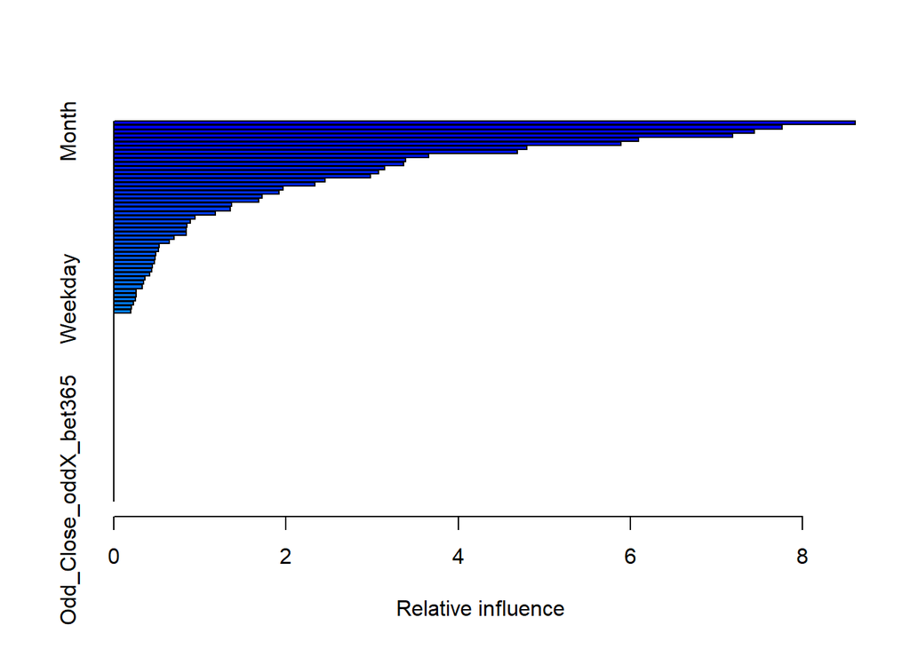

```
##                                                   var   rel.inf
## Odd_Close_odd2_Betclic         Odd_Close_odd2_Betclic 8.6082273
## Odd_Open_odd1_WilliamHill   Odd_Open_odd1_WilliamHill 7.7597034
## Month                                           Month 7.4342919
## Odd_Open_odd1_Betsafe           Odd_Open_odd1_Betsafe 7.1876854
## Odd_Open_odd1_betathome       Odd_Open_odd1_betathome 6.0950448
## Odd_Close_odd2_bwin               Odd_Close_odd2_bwin 5.8914521
## Odd_Close_odd2_Betsson         Odd_Close_odd2_Betsson 4.7953470
## Odd_Open_odd2_Betsafe           Odd_Open_odd2_Betsafe 4.6894699
## Odd_Open_odd1_bwin                 Odd_Open_odd1_bwin 3.6554847
## Odd_Open_oddX_Betsafe           Odd_Open_oddX_Betsafe 3.3900136
## Odd_Open_odd1_10Bet               Odd_Open_odd1_10Bet 3.3674775
## Odd_Close_odd1_12BET             Odd_Close_odd1_12BET 3.1444246
## Odd_Close_odd1_bwin               Odd_Close_odd1_bwin 3.0762009
## Odd_Close_odd1_BetVictor     Odd_Close_odd1_BetVictor 2.9791411
## Odd_Close_odd2_12BET             Odd_Close_odd2_12BET 2.4513000
## Odd_Close_odd2_Betsafe         Odd_Close_odd2_Betsafe 2.3384992
## Odd_Close_odd1_SBOBET           Odd_Close_odd1_SBOBET 1.9668380
## Odd_Open_odd2_Betway             Odd_Open_odd2_Betway 1.9176388
## Odd_Close_oddX_12BET             Odd_Close_oddX_12BET 1.7208656
## Odd_Close_odd1_188BET           Odd_Close_odd1_188BET 1.6863552
## Odd_Open_odd2_Betsson           Odd_Open_odd2_Betsson 1.3712380
## Odd_Open_odd1_Betsson           Odd_Open_odd1_Betsson 1.3515146
## Odd_Open_oddX_Betclic           Odd_Open_oddX_Betclic 1.1776137
## Odd_Open_odd1_Unibet             Odd_Open_odd1_Unibet 0.9438673
## Odd_Close_oddX_betathome     Odd_Close_oddX_betathome 0.8920889
## Match_Hour                                 Match_Hour 0.8505369
## Odd_Open_odd2_Pinnacle         Odd_Open_odd2_Pinnacle 0.8424985
## Odd_Open_oddX_Betsson           Odd_Open_oddX_Betsson 0.8403629
## Odd_Close_oddX_SBOBET           Odd_Close_oddX_SBOBET 0.6984725
## Odd_Open_oddX_WilliamHill   Odd_Open_oddX_WilliamHill 0.6428006
## Odd_Open_odd2_Unibet             Odd_Open_odd2_Unibet 0.5255792
## Odd_Close_odd2_WilliamHill Odd_Close_odd2_WilliamHill 0.5190732
## Odd_Close_odd1_Betsafe         Odd_Close_odd1_Betsafe 0.4856077
## Odd_Open_oddX_BetVictor       Odd_Open_oddX_BetVictor 0.4810495
## Odd_Open_oddX_188BET             Odd_Open_oddX_188BET 0.4686534
## Odd_Close_oddX_Pinnacle       Odd_Close_oddX_Pinnacle 0.4481871
## Odd_Open_odd1_Betway             Odd_Open_odd1_Betway 0.4415479
## Odd_Close_oddX_bwin               Odd_Close_oddX_bwin 0.4169675
## Odd_Open_oddX_bet365             Odd_Open_oddX_bet365 0.3638161
```

[output cut: 39 more lines]

```
## Odd_Close_odd2_188BET           Odd_Close_odd2_188BET 0.0000000
## Odd_Close_odd2_BetVictor     Odd_Close_odd2_BetVictor 0.0000000
## Odd_Close_odd2_Betway           Odd_Close_odd2_Betway 0.0000000
## Odd_Close_odd2_Pinnacle       Odd_Close_odd2_Pinnacle 0.0000000
## Odd_Close_odd2_Unibet           Odd_Close_odd2_Unibet 0.0000000
## Odd_Close_odd2_bet365           Odd_Close_odd2_bet365 0.0000000
## Odd_Close_oddX_10Bet             Odd_Close_oddX_10Bet 0.0000000
## Odd_Close_oddX_188BET           Odd_Close_oddX_188BET 0.0000000
## Odd_Close_oddX_BetVictor     Odd_Close_oddX_BetVictor 0.0000000
## Odd_Close_oddX_Betsafe         Odd_Close_oddX_Betsafe 0.0000000
## Odd_Close_oddX_Betsson         Odd_Close_oddX_Betsson 0.0000000
## Odd_Close_oddX_Betway           Odd_Close_oddX_Betway 0.0000000
## Odd_Close_oddX_Unibet           Odd_Close_oddX_Unibet 0.0000000
## Odd_Close_oddX_WilliamHill Odd_Close_oddX_WilliamHill 0.0000000
## Odd_Close_oddX_bet365           Odd_Close_oddX_bet365 0.0000000
```

```
## [1] "Average RPS for traindata (stochastic gradient boosting)"
## [2] "0.180025085138871"
```

Average rps value was obtained for train data. Now, the model will be used for predicting the probabilities of possible outcomes of match result for the test data.

```
## [1] "Predictions for round 17 (stochastic gradient boosting)"
```

```
##      matchId            home           away      Home       Tie       Away
##  1: 4xkH5hrL  crystal-palace      leicester 0.3611885 0.4537491 0.18506246
##  2: EBzm0W5r    huddersfield      newcastle 0.2172645 0.6732296 0.10950595
##  3: h2ZjajLl       liverpool manchester-utd 0.6512386 0.2258733 0.12288817
##  4: hzgduVtp         watford        cardiff 0.5681888 0.3385485 0.09326269
##  5: lUSacUk1     southampton        arsenal 0.2471091 0.3231204 0.42977058
##  6: MDaC6YSE        brighton        chelsea 0.1265042 0.1693260 0.70416974
##  7: MsR7e8KD          wolves    bournemouth 0.4126016 0.4383337 0.14906478
##  8: riS3dl57       tottenham        burnley 0.7935909 0.1741185 0.03229068
##  9: rTmL4CcR          fulham       west-ham 0.2881824 0.4609499 0.25086762
## 10: zROebAze manchester-city        everton 0.8229845 0.1389358 0.03807977
```

### RPS Calculations for Predicted Matches

After getting the match results, average RPS values were calculated for the outcomes of two algorithms.

```
## [1] "Average RPS for test data (multinomial penalized logistic regression)"
## [2] "0.169404868891296"
```

```
## [1] "Average RPS for testdata (stochastic gradient boosting)"
## [2] "0.177870536292924"
```

## Round 18

### Multinomial Logistic Regression Model (with l1 penalty, i.e. LASSO)

```
## Number of bookmakers with proportion of missings below 0.01 since 2012-07-15 : 15
## Number of bookmakers with no missings since testStart 2018-12-21 : 2
```

```
## [1] "Average RPS for train data (multinomial penalized logistic regression)"
## [2] "0.192433302993929"
```

Average rps value was obtained for train data. Now, the model will be used for predicting the probabilities of possible outcomes of match result for the test data.

```
## [1] "Predictions for round 18 (multinomial penalized logistic regression)"
```

```
##      matchId            home           away      Home        Tie
##  1: 6Rxtx2Zb    huddersfield    southampton 0.3856826 0.28057072
##  2: Eitlzt4B       newcastle         fulham 0.4642561 0.28516038
##  3: O2mywrKh         everton      tottenham 0.3536769 0.28221775
##  4: QHUXwO4n         chelsea      leicester 0.6645530 0.19502082
##  5: WfVTv4kt     bournemouth       brighton 0.4787893 0.28121338
##  6: fV70dWKD         arsenal        burnley 0.7901373 0.12341432
##  7: hruhZaJH        west-ham        watford 0.4211963 0.29314376
##  8: pIypyMl5 manchester-city crystal-palace 0.8775320 0.07279848
##  9: z7UdYJYN          wolves      liverpool 0.2064026 0.18677679
## 10: zar1vkdj         cardiff manchester-utd 0.2221759 0.19944940
##           Away
##  1: 0.33374664
##  2: 0.25058355
##  3: 0.36410536
##  4: 0.14042615
##  5: 0.23999736
##  6: 0.08644840
##  7: 0.28565996
##  8: 0.04966954
##  9: 0.60682062
## 10: 0.57837469
```

### Stochastic Gradient Boosting

```
## [1] "Relative influences of the features"
```

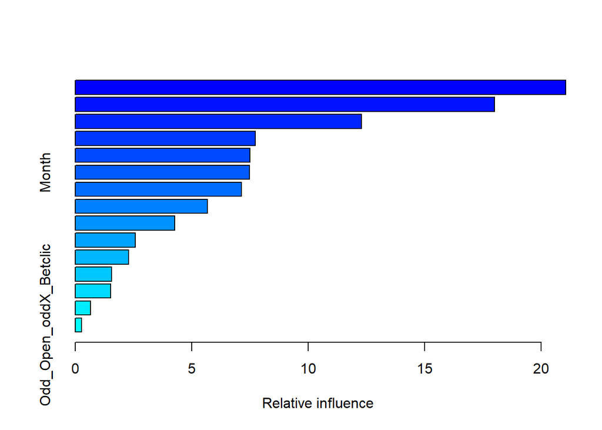

```
##                                               var    rel.inf
## Odd_Close_odd2_Betclic     Odd_Close_odd2_Betclic 21.0524150
## Odd_Close_odd2_betathome Odd_Close_odd2_betathome 17.9953294
## Odd_Close_odd1_betathome Odd_Close_odd1_betathome 12.2894322
## Odd_Open_odd2_betathome   Odd_Open_odd2_betathome  7.7275766
## Odd_Open_odd2_Betclic       Odd_Open_odd2_Betclic  7.5084133
## Month                                       Month  7.4732451
## Odd_Open_odd1_Betclic       Odd_Open_odd1_Betclic  7.1349067
## Odd_Open_odd1_betathome   Odd_Open_odd1_betathome  5.6717688
## Odd_Open_oddX_betathome   Odd_Open_oddX_betathome  4.2664795
## Odd_Close_oddX_Betclic     Odd_Close_oddX_Betclic  2.5847724
## Odd_Close_odd1_Betclic     Odd_Close_odd1_Betclic  2.2894390
## Match_Hour                             Match_Hour  1.5651124
## Odd_Close_oddX_betathome Odd_Close_oddX_betathome  1.5122340
## Weekday                                   Weekday  0.6582676
## Odd_Open_oddX_Betclic       Odd_Open_oddX_Betclic  0.2706078
```

```
## [1] "Average RPS for traindata (stochastic gradient boosting)"
## [2] "0.183636069340467"
```

Average rps value was obtained for train data. Now, the model will be used for predicting the probabilities of possible outcomes of match result for the test data.

```
## [1] "Predictions for round 18 (stochastic gradient boosting)"
```

```
##      matchId            home           away      Home       Tie       Away
##  1: 6Rxtx2Zb    huddersfield    southampton 0.2707187 0.5121828 0.21709846
##  2: Eitlzt4B       newcastle         fulham 0.3736098 0.4894524 0.13693776
##  3: fV70dWKD         arsenal        burnley 0.7680311 0.1909509 0.04101793
##  4: hruhZaJH        west-ham        watford 0.2656658 0.5738923 0.16044186
##  5: O2mywrKh         everton      tottenham 0.3134493 0.3137329 0.37281776
##  6: pIypyMl5 manchester-city crystal-palace 0.8162800 0.1568849 0.02683505
##  7: QHUXwO4n         chelsea      leicester 0.7112909 0.2265910 0.06211809
##  8: WfVTv4kt     bournemouth       brighton 0.4342919 0.4322667 0.13344144
##  9: z7UdYJYN          wolves      liverpool 0.1631178 0.2347583 0.60212397
## 10: zar1vkdj         cardiff manchester-utd 0.1249403 0.2687362 0.60632347
```

### RPS Calculations for Predicted Matches

After getting the match results, average RPS values were calculated for the outcomes of two algorithms.

```
## [1] "Average RPS for test data (multinomial penalized logistic regression)"
## [2] "0.287344662591971"
```

```
## [1] "Average RPS for testdata (stochastic gradient boosting)"
## [2] "0.292967630972852"
```

## Round 20

### Multinomial Logistic Regression Model (with l1 penalty, i.e. LASSO)

```
## Number of bookmakers with proportion of missings below 0.01 since 2012-07-15 : 15
## Number of bookmakers with no missings since testStart 2018-12-29 : 15
```

```
## [1] "Average RPS for train data (multinomial penalized logistic regression)"
## [2] "0.192605831300802"
```

Average rps value was obtained for train data. Now, the model will be used for predicting the probabilities of possible outcomes of match result for the test data.

```
## [1] "Predictions for round 20 (multinomial penalized logistic regression)"
```

```
##      matchId           home            away      Home       Tie      Away
##  1: 0Uu6adXM        watford       newcastle 0.4731977 0.2870818 0.2397205
##  2: 25zm2hlc      leicester         cardiff 0.5405133 0.2594426 0.2000441
##  3: 67t20xIG      tottenham          wolves 0.6351045 0.2119783 0.1529172
##  4: Aumg2bm4 manchester-utd     bournemouth 0.6132820 0.2249775 0.1617405
##  5: MwLWpcIT       brighton         everton 0.3544489 0.2836153 0.3619358
##  6: On7btHQp        burnley        west-ham 0.3592065 0.2849270 0.3558664
##  7: Qios503o crystal-palace         chelsea 0.2754278 0.2412366 0.4833356
##  8: SGsb1I2A    southampton manchester-city 0.1060482 0.1027443 0.7912076
##  9: Wllk3vYc      liverpool         arsenal 0.5424338 0.2609108 0.1966553
## 10: xSlo4KIi         fulham    huddersfield 0.4426933 0.2933444 0.2639623
```

### Stochastic Gradient Boosting

```
## [1] "Relative influences of the features"
```

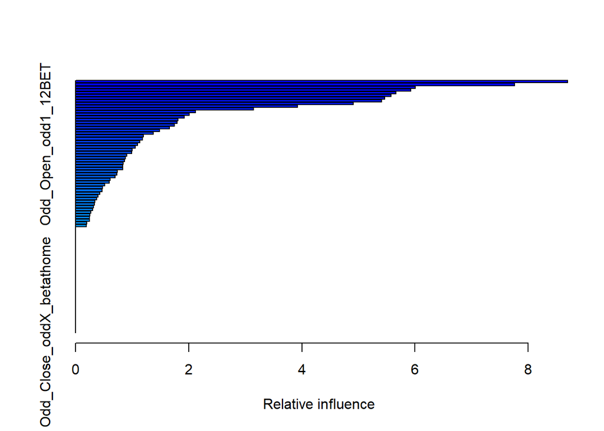

```
##                                                   var   rel.inf
## Odd_Close_odd2_bwin               Odd_Close_odd2_bwin 8.6959043
## Odd_Close_odd2_Pinnacle       Odd_Close_odd2_Pinnacle 7.7614098
## Odd_Close_odd1_SBOBET           Odd_Close_odd1_SBOBET 6.0039924
## Month                                           Month 5.9227921
## Odd_Open_odd2_Betsafe           Odd_Open_odd2_Betsafe 5.6594644
## Odd_Open_odd2_12BET               Odd_Open_odd2_12BET 5.5787595
## Odd_Open_odd1_Betclic           Odd_Open_odd1_Betclic 5.4671012
## Odd_Open_odd1_BetVictor       Odd_Open_odd1_BetVictor 5.4053316
## Odd_Close_odd2_188BET           Odd_Close_odd2_188BET 4.9095625
## Odd_Open_odd2_Betsson           Odd_Open_odd2_Betsson 3.9231068
## Odd_Close_odd2_Betclic         Odd_Close_odd2_Betclic 3.1477253
## Odd_Open_odd2_Betway             Odd_Open_odd2_Betway 2.1183907
## Odd_Close_odd2_betathome     Odd_Close_odd2_betathome 2.0100681
## Odd_Open_odd2_SBOBET             Odd_Open_odd2_SBOBET 1.9244560
## Odd_Close_odd1_188BET           Odd_Close_odd1_188BET 1.8132836
## Odd_Close_oddX_188BET           Odd_Close_oddX_188BET 1.7971892
## Odd_Close_odd2_12BET             Odd_Close_odd2_12BET 1.7452753
## Odd_Close_odd1_bet365           Odd_Close_odd1_bet365 1.6568106
## Odd_Open_oddX_Betsson           Odd_Open_oddX_Betsson 1.4848321
## Weekday                                       Weekday 1.3746907
## Match_Hour                                 Match_Hour 1.2002453
## Odd_Close_oddX_12BET             Odd_Close_oddX_12BET 1.1848501
## Odd_Open_oddX_Betclic           Odd_Open_oddX_Betclic 1.1342650
## Odd_Open_odd1_12BET               Odd_Open_odd1_12BET 1.1007499
## Odd_Close_odd1_BetVictor     Odd_Close_odd1_BetVictor 1.0610419
## Odd_Open_odd1_bet365             Odd_Open_odd1_bet365 0.9984767
## Odd_Open_oddX_WilliamHill   Odd_Open_oddX_WilliamHill 0.9932166
## Odd_Open_odd1_10Bet               Odd_Open_odd1_10Bet 0.9024525
## Odd_Open_oddX_bet365             Odd_Open_oddX_bet365 0.8858936
## Odd_Close_odd2_Betsafe         Odd_Close_odd2_Betsafe 0.8677233
## Odd_Close_odd1_12BET             Odd_Close_odd1_12BET 0.8445887
## Odd_Open_odd1_Betsafe           Odd_Open_odd1_Betsafe 0.8359230
## Odd_Open_oddX_12BET               Odd_Open_oddX_12BET 0.8318700
## Odd_Close_oddX_BetVictor     Odd_Close_oddX_BetVictor 0.7359652
## Odd_Open_odd1_SBOBET             Odd_Open_odd1_SBOBET 0.7286070
## Odd_Open_oddX_SBOBET             Odd_Open_oddX_SBOBET 0.7036639
## Odd_Open_oddX_betathome       Odd_Open_oddX_betathome 0.6127279
## Odd_Close_odd1_10Bet             Odd_Close_odd1_10Bet 0.5998007
## Odd_Open_oddX_Betsafe           Odd_Open_oddX_Betsafe 0.5150571
```

[output cut: 39 more lines]

```
## Odd_Close_odd2_10Bet             Odd_Close_odd2_10Bet 0.0000000
## Odd_Close_odd2_BetVictor     Odd_Close_odd2_BetVictor 0.0000000
## Odd_Close_odd2_Betsson         Odd_Close_odd2_Betsson 0.0000000
## Odd_Close_odd2_Betway           Odd_Close_odd2_Betway 0.0000000
## Odd_Close_odd2_Unibet           Odd_Close_odd2_Unibet 0.0000000
## Odd_Close_odd2_WilliamHill Odd_Close_odd2_WilliamHill 0.0000000
## Odd_Close_odd2_bet365           Odd_Close_odd2_bet365 0.0000000
## Odd_Close_oddX_10Bet             Odd_Close_oddX_10Bet 0.0000000
## Odd_Close_oddX_Betclic         Odd_Close_oddX_Betclic 0.0000000
## Odd_Close_oddX_Betsafe         Odd_Close_oddX_Betsafe 0.0000000
## Odd_Close_oddX_Betsson         Odd_Close_oddX_Betsson 0.0000000
## Odd_Close_oddX_SBOBET           Odd_Close_oddX_SBOBET 0.0000000
## Odd_Close_oddX_WilliamHill Odd_Close_oddX_WilliamHill 0.0000000
## Odd_Close_oddX_bet365           Odd_Close_oddX_bet365 0.0000000
## Odd_Close_oddX_betathome     Odd_Close_oddX_betathome 0.0000000
```

```
## [1] "Average RPS for traindata (stochastic gradient boosting)"
## [2] "0.180890515271439"
```

Average rps value was obtained for train data. Now, the model will be used for predicting the probabilities of possible outcomes of match result for the test data.

```
## [1] "Predictions for round 20 (stochastic gradient boosting)"
```

```
##      matchId           home            away      Home       Tie       Away
##  1: 0Uu6adXM        watford       newcastle 0.4817799 0.3806688 0.13755127
##  2: 25zm2hlc      leicester         cardiff 0.5668860 0.3240132 0.10910072
##  3: 67t20xIG      tottenham          wolves 0.6903042 0.2303806 0.07931512
##  4: Aumg2bm4 manchester-utd     bournemouth 0.7725296 0.1466131 0.08085734
##  5: MwLWpcIT       brighton         everton 0.2392735 0.3683215 0.39240499
##  6: On7btHQp        burnley        west-ham 0.4221865 0.1918978 0.38591566
##  7: Qios503o crystal-palace         chelsea 0.2513779 0.2820015 0.46662059
##  8: SGsb1I2A    southampton manchester-city 0.1166049 0.1824936 0.70090148
##  9: Wllk3vYc      liverpool         arsenal 0.5678327 0.3136540 0.11851331
## 10: xSlo4KIi         fulham    huddersfield 0.4573641 0.3378995 0.20473644
```

### RPS Calculations for Predicted Matches

After getting the match results, average RPS values were calculated for the outcomes of two algorithms.

```
## [1] "Average RPS for test data (multinomial penalized logistic regression)"
## [2] "0.231051239719653"
```

```
## [1] "Average RPS for testdata (stochastic gradient boosting)"
## [2] "0.24759832166663"
```

## Round 21

### Multinomial Logistic Regression Model (with l1 penalty, i.e. LASSO)

```
## Number of bookmakers with proportion of missings below 0.01 since 2012-07-15 : 15
## Number of bookmakers with no missings since testStart 2018-12-31 : 15
```

```
## [1] "Average RPS for train data (multinomial penalized logistic regression)"
## [2] "0.192809339031446"
```

Average rps value was obtained for train data. Now, the model will be used for predicting the probabilities of possible outcomes of match result for the test data.

```
## [1] "Predictions for round 21 (multinomial penalized logistic regression)"
```

```
##      matchId            home           away      Home       Tie      Away
##  1: CMONHwmi         everton      leicester 0.4435915 0.2963509 0.2600576
##  2: EXqAbGnT         arsenal         fulham 0.6481821 0.2054413 0.1463766
##  3: KEMxfzep     bournemouth        watford 0.4094215 0.2978550 0.2927236
##  4: KhFrDF1M          wolves crystal-palace 0.4448742 0.2947624 0.2603634
##  5: YyDWFHH3 manchester-city      liverpool 0.4383313 0.2949274 0.2667413
##  6: b5LtgfAj         chelsea    southampton 0.6589510 0.1996008 0.1414482
##  7: jDNRGc2c    huddersfield        burnley 0.4353909 0.2943513 0.2702578
##  8: nuHzFyX9       newcastle manchester-utd 0.3075491 0.2629344 0.4295165
##  9: t2GvEenG        west-ham       brighton 0.4548572 0.2935475 0.2515953
## 10: tdZj1C33         cardiff      tottenham 0.2086467 0.1912582 0.6000951
```

### Stochastic Gradient Boosting

```
## [1] "Relative influences of the features"
```

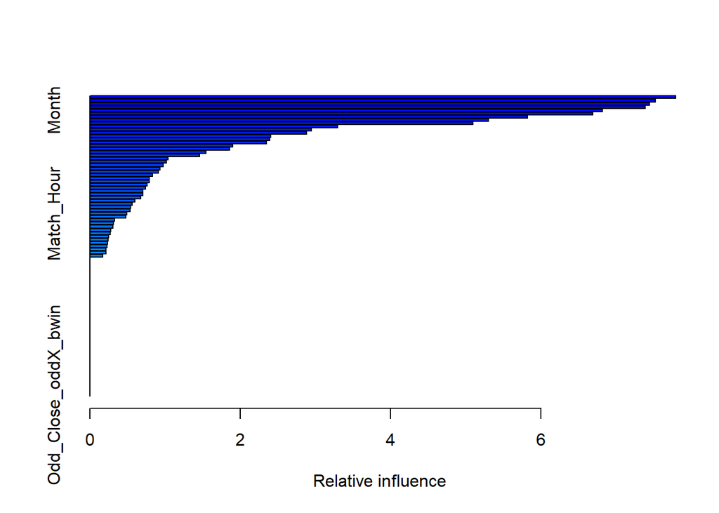

```
##                                                   var   rel.inf
## Odd_Open_odd1_Betway             Odd_Open_odd1_Betway 7.7892816
## Odd_Close_odd2_188BET           Odd_Close_odd2_188BET 7.5176568
## Odd_Close_odd1_10Bet             Odd_Close_odd1_10Bet 7.4383222
## Odd_Open_odd1_12BET               Odd_Open_odd1_12BET 7.3859019
## Month                                           Month 6.8186933
## Odd_Close_odd2_Betsson         Odd_Close_odd2_Betsson 6.6869677
## Odd_Close_odd1_WilliamHill Odd_Close_odd1_WilliamHill 5.8194681
## Odd_Close_odd2_bwin               Odd_Close_odd2_bwin 5.2971303
## Odd_Close_odd2_12BET             Odd_Close_odd2_12BET 5.0944678
## Odd_Close_odd2_Betsafe         Odd_Close_odd2_Betsafe 3.2946561
## Odd_Close_odd1_betathome     Odd_Close_odd1_betathome 2.9430722
## Odd_Close_odd1_Betclic         Odd_Close_odd1_Betclic 2.8817973
## Odd_Close_odd2_Unibet           Odd_Close_odd2_Unibet 2.4043442
## Odd_Close_odd1_SBOBET           Odd_Close_odd1_SBOBET 2.3874955
## Odd_Close_oddX_12BET             Odd_Close_oddX_12BET 2.3467403
## Odd_Close_odd1_Betsafe         Odd_Close_odd1_Betsafe 1.8985071
## Odd_Open_odd1_SBOBET             Odd_Open_odd1_SBOBET 1.8568526
## Odd_Open_oddX_Betsson           Odd_Open_oddX_Betsson 1.5439173
## Odd_Open_oddX_Betway             Odd_Open_oddX_Betway 1.4562138
## Odd_Close_odd1_Betsson         Odd_Close_odd1_Betsson 1.0367324
## Odd_Open_odd2_Pinnacle         Odd_Open_odd2_Pinnacle 1.0190076
## Odd_Close_oddX_betathome     Odd_Close_oddX_betathome 0.9771932
## Odd_Close_odd2_bet365           Odd_Close_odd2_bet365 0.9336024
## Odd_Close_odd1_12BET             Odd_Close_odd1_12BET 0.9125756
## Odd_Close_odd1_188BET           Odd_Close_odd1_188BET 0.8363086
## Odd_Close_odd1_Unibet           Odd_Close_odd1_Unibet 0.7880564
## Odd_Open_odd1_Betsafe           Odd_Open_odd1_Betsafe 0.7878939
## Odd_Open_oddX_bet365             Odd_Open_oddX_bet365 0.7613364
## Odd_Close_odd2_Betclic         Odd_Close_odd2_Betclic 0.7387394
## Odd_Open_oddX_188BET             Odd_Open_oddX_188BET 0.7055804
## Weekday                                       Weekday 0.7043590
## Odd_Open_odd1_Betsson           Odd_Open_odd1_Betsson 0.6742009
## Odd_Open_oddX_Pinnacle         Odd_Open_oddX_Pinnacle 0.6005843
## Odd_Open_odd2_bwin                 Odd_Open_odd2_bwin 0.5617022
## Odd_Close_oddX_188BET           Odd_Close_oddX_188BET 0.5393788
## Odd_Open_oddX_BetVictor       Odd_Open_oddX_BetVictor 0.5335010
## Match_Hour                                 Match_Hour 0.4949811
## Odd_Close_odd2_Pinnacle       Odd_Close_odd2_Pinnacle 0.4755518
## Odd_Open_oddX_Betclic           Odd_Open_oddX_Betclic 0.3263347
```

[output cut: 39 more lines]

```
## Odd_Close_odd2_10Bet             Odd_Close_odd2_10Bet 0.0000000
## Odd_Close_odd2_BetVictor     Odd_Close_odd2_BetVictor 0.0000000
## Odd_Close_odd2_SBOBET           Odd_Close_odd2_SBOBET 0.0000000
## Odd_Close_odd2_WilliamHill Odd_Close_odd2_WilliamHill 0.0000000
## Odd_Close_odd2_betathome     Odd_Close_odd2_betathome 0.0000000
## Odd_Close_oddX_10Bet             Odd_Close_oddX_10Bet 0.0000000
## Odd_Close_oddX_BetVictor     Odd_Close_oddX_BetVictor 0.0000000
## Odd_Close_oddX_Betsafe         Odd_Close_oddX_Betsafe 0.0000000
## Odd_Close_oddX_Betsson         Odd_Close_oddX_Betsson 0.0000000
## Odd_Close_oddX_Betway           Odd_Close_oddX_Betway 0.0000000
## Odd_Close_oddX_Pinnacle       Odd_Close_oddX_Pinnacle 0.0000000
## Odd_Close_oddX_SBOBET           Odd_Close_oddX_SBOBET 0.0000000
## Odd_Close_oddX_WilliamHill Odd_Close_oddX_WilliamHill 0.0000000
## Odd_Close_oddX_bet365           Odd_Close_oddX_bet365 0.0000000
## Odd_Close_oddX_bwin               Odd_Close_oddX_bwin 0.0000000
```

```
## [1] "Average RPS for traindata (stochastic gradient boosting)"
## [2] "0.180674038695689"
```

Average rps value was obtained for train data. Now, the model will be used for predicting the probabilities of possible outcomes of match result for the test data.

```
## [1] "Predictions for round 21 (stochastic gradient boosting)"
```

```
##      matchId            home           away      Home       Tie       Away
##  1: b5LtgfAj         chelsea    southampton 0.7639167 0.1578073 0.07827597
##  2: CMONHwmi         everton      leicester 0.4867357 0.3322872 0.18097717
##  3: EXqAbGnT         arsenal         fulham 0.7694941 0.1560437 0.07446219
##  4: jDNRGc2c    huddersfield        burnley 0.4791719 0.2830959 0.23773213
##  5: KEMxfzep     bournemouth        watford 0.3920341 0.3967389 0.21122695
##  6: KhFrDF1M          wolves crystal-palace 0.4971958 0.3164522 0.18635204
##  7: nuHzFyX9       newcastle manchester-utd 0.1954432 0.2533527 0.55120415
##  8: t2GvEenG        west-ham       brighton 0.5156204 0.3109333 0.17344636
##  9: tdZj1C33         cardiff      tottenham 0.1865966 0.2354580 0.57794537
## 10: YyDWFHH3 manchester-city      liverpool 0.4456428 0.3844712 0.16988591
```

### RPS Calculations for Predicted Matches

After getting the match results, average RPS values were calculated for the outcomes of two algorithms.

```
## [1] "Average RPS for test data (multinomial penalized logistic regression)"
## [2] "0.217220222484091"
```

```
## [1] "Average RPS for testdata (stochastic gradient boosting)"
## [2] "0.227948051500041"
```

# CONCLUSIONS AND FUTURE WORK

Both multinomial logistic regression model (lasso penalty) and stochastic gradient boosting are tried for each submission, and the one which is expected to give better results is uploaded on the system. While choosing the method to use, the prediction results on test data and RPS values of the previous weeks are taken into consideration. When the RPS calculation is done on the train data, the results were close to each other for multinomial logistic regression model (lasso penalty) and stochastic gradient boosting, however stochastic gradient boosting had slightly lower RPS results. However, when the RPS calculations are done on the test data, multinomial logistic regression model (lasso) was the method that generally gives better RPS values compared to stochastic gradient boosting results on the test data. The reason of multinomial logistic regression model (lasso penalty) giving lower RPS values compared to stochastic gradient boosting on test data is that, when there is low number of matches to be predicted, multinomial logistic regression model is more robust for unexpected results of surprise matches. If there were a greater number of matches to be predicted (more than 10 matches for this project), stochastic gradient boosting could have given better results, because there should be no overfitting since cross validation is done.

For a better approach, PCA could have been applied or multidimensional scaling could have been done as possible extensions, before the analyses. PCA helps to visualize the results, since most people can only understand at most tree dimensions to make conclusions on the findings. And PCA minimizes the loss of data by keeping the variation at its maximum level as much as possible while decreasing the number of dimensions to an understandable level. Using multidimensional scaling would also help for visualization of the data instead of showing numbers. In multidimensional scaling, the similar variables are closer to each other compared to the far away variables in terms of similarity measures.

# REFERENCES

[[1] Friedman, J. H. (2002). Stochastic gradient boosting. Computational Statistics & Data Analysis, 38(4), 367-378.](https://www.sciencedirect.com/science/article/pii/S0167947301000652)

[[2] Bunker, R. P., & Thabtah, F. (2017). A machine learning framework for sport result prediction. Applied Computing and Informatics.](https://www.sciencedirect.com/science/article/pii/S2210832717301485)

[[3] [Importance of lambda value in multinomial penalized logistic regression]. (2016). Retrieved from https://stats.stackexchange.com/questions/151247/how-to-choose-lambda-value-while-working-with-elsaticnet-package](https://stats.stackexchange.com/questions/151247/how-to-choose-lambda-value-while-working-with-elsaticnet-package)

# R CODE

[Click Here to see R Code](https://github.com/BU-IE-582/fall18-ahmetpala/blob/master/files/Project-Lastversioncodes.R)